# Who buys what?

Plant material licensing for LGU Agricultural Colleges, 1980-2020

Adam Vera

2023-05-11

This report analyzes agricultural product licenses from land grant universities and the companies that purchase such products. This analysis explores the role specific universities have in this market, the breakdown of crops per region, and the financial status of companies.

# Licenses

## License data frame column names and descriptions:

1. X: Row Number
2. crop_name_common: common name of each crop
3. crop_name_scientific: scientific name of each crop with genus and species
4. variety_name: name of specific variety given by the inventor
5. licensee: buyer of license
6. agreement_type: type of agreement between licensee and uni_state; for example: exclusive, non-exclusive, etc.
7. effective_date: date of purchase/license
8. end_date: termination date of license agreement
9. uni_state: state of university
10. ip_name: intellectual property crop name
11. fao_class1: general classification of crop given by Food and Agricultural Organization (FAO)
12. fao_class2: more specific classification of crop given by FAO
13. ornamental: marks whether the crop is an ornamental (TRUE) or not (FALSE)
14. orn_use: type of ornamental for such crops that are TRUE
15. crop_cat: same as fao_class1 with proper formatting

## Licenses from a temporal view

Licenses can be grouped into five year time periods to determine the total number of licenses across all universities in the data frame and present changes in annual license total. To accurately represent this, manipulations of the data frame is required to determine the effective year of the license as well as group licenses into five year periods. The time periods begin in 1996 until the end of 2000 and end at the end of 2020 when data availability became inconsistent. All licenses formed earlier than 1996 are considered as “Older”.

```r
years <-  as.Date(licenses$effective_date, '%Y-%m-%d')

effective_year <- as.numeric(format((as.Date(licenses$effective_date, '%Y-%m-%d')),'%Y'))

licenses <- licenses %>%
  mutate(effective_year = as.numeric(format((as.Date(effective_date, '%Y-%m-%d')),'%Y')))

licenses <- licenses %>%
  filter(effective_year < 2021) %>%
  mutate(year_range = case_when(effective_year > 2015 ~ "2016-2020", effective_year > 2010 ~ "2011-2015", effective_year > 2005 ~ "2006-2010", effective_year > 2000 ~ "2001-2005", effective_year > 1995 ~ "1996-2000", TRUE ~ "Older"))
```

Running the code below determines which universities are the most active. Based on its result, the top five universities by license count are considered to be top universities, while the remaining twenty universities are considered to be “Other”. This is represented in a plot below per five year time period.

```r
licenses %>%
  group_by(uni_state) %>%
  count() %>%
  arrange(-n)
```

```
## # A tibble: 25 × 2
## # Groups:   uni_state [25]
##    uni_state          n
##    <chr>          <int>
##  1 Washington      2378
##  2 Oregon          1004
##  3 North Carolina   883
##  4 Texas            672
##  5 Iowa             526
##  6 Michigan         294
##  7 Louisiana        249
##  8 California       210
##  9 Minnesota        186
## 10 Idaho            130
## # … with 15 more rows
```

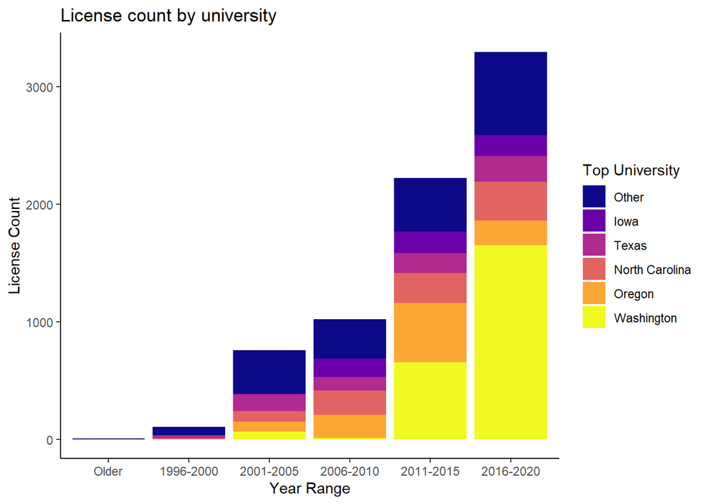

```r
top_uni_list <- c("Washington", "Oregon", "North Carolina", "Texas", "Iowa")

licenses <- licenses %>%
  mutate(top_uni = case_when(uni_state %in% top_uni_list ~ uni_state, TRUE ~ "Other"))

licenses$top_uni <- factor(licenses$top_uni, levels = c("Other", "Iowa", "Texas", "North Carolina", "Oregon", "Washington"))

ggplot(licenses, aes(x = factor(year_range, level=c('Older', '1996-2000', '2001-2005', '2006-2010', '2011-2015', '2016-2020')), fill = top_uni)) +
  geom_bar() +
  theme(axis.text.x = element_text(angle=70, vjust=0.5)) +
  scale_fill_viridis_d(option = "C") +
  labs(title = "License count by university",
       x = "Year Range", y = "License Count", fill = "Top University") +
  theme_classic()
```

## Licenses per crop type

Crop type is resembled by FAO class, and can be grouped with university to determine the percentage that each university contributes to each crop type. NAs values for FAO class mostly resemble ornamental crops and have been removed. This report is more focused on food and cash crops.

```r
licenses %>%
  filter(!is.na(fao_class1)) %>%
  count()
```

```
##      n
## 1 7028
```

```r
licenses %>%
  filter(!is.na(fao_class1)) %>%
  group_by(fao_class1) %>%
  count() %>%
  arrange(-n)
```

```
## # A tibble: 11 × 2
## # Groups:   fao_class1 [11]
##    fao_class1         n
##    <chr>          <int>
##  1 cereals         3232
##  2 fruits_nuts     1224
##  3 oilseeds        1113
##  4 veg_melon        756
##  5 root_tuber       422
##  6 non_food         145
##  7 grasses_fodder    64
##  8 leguminous        44
##  9 spice_crops       17
## 10 medicinal         10
## 11 sugar_crops        1
```

```r
licenses %>%
  group_by(fao_class1, uni_state) %>%
  count() %>%
  arrange(-n)
```

```
## # A tibble: 103 × 3
## # Groups:   fao_class1, uni_state [103]
##    fao_class1  uni_state          n
##    <chr>       <chr>          <int>
##  1 cereals     Washington      2122
##  2 oilseeds    Iowa             517
##  3 cereals     Oregon           485
##  4 veg_melon   North Carolina   406
##  5 fruits_nuts Oregon           285
##  6 fruits_nuts Washington       239
##  7 fruits_nuts California       199
##  8 root_tuber  Oregon           191
##  9 veg_melon   Louisiana        190
## 10 cereals     Texas            176
## # … with 93 more rows
```

The crop licensed the most of all FAO classes is cereals, making up 3232 of the 7028 licenses. Washington dominates the cereal market at 2122 licenses, licensing 65.7% (2122/3232) of cereals. With this code, the percentage of any crop in any state out of all available license data can be calculated.

This report comes from researchers at the University of California, Davis; therefore, observations about UC Davis’ role in the market is interesting. Below, it is shown that California primarily produces fruits and nuts and all licenses are sold via exclusive licenses.

```r
licenses_ca <- licenses %>%
  filter(uni_state == "California")

licenses_ca %>%
  group_by(fao_class1) %>%
  count() %>%
  arrange(-n)
```

```
## # A tibble: 4 × 2
## # Groups:   fao_class1 [4]
##   fao_class1      n
##   <chr>       <int>
## 1 fruits_nuts   199
## 2 cereals         9
## 3 root_tuber      1
## 4 veg_melon       1
```

```r
licenses_ca %>%
  group_by(agreement_type) %>%
  count() %>%
  arrange(-n)
```

```
## # A tibble: 1 × 2
## # Groups:   agreement_type [1]
##   agreement_type        n
##   <chr>             <int>
## 1 Exclusive license   210
```

# Companies

```
##  [1] "X"                      "dnb_name"               "company_type"
##  [4] "website"                "parent"                 "corp_link"
##  [7] "industry"               "currency"               "assets"
## [10] "duns"                   "address"                "naics2017"
## [13] "yr_founded"             "incorp_location"        "local_employee_number"
## [16] "total_employee_number"  "global_employee_number" "local_sales_number"
## [19] "global_sales_number"    "db_type"                "licensee"
## [22] "zipcode"                "lat"                    "long"
## [25] "country"                "state"                  "domestic"
## [28] "licensee_type"
```

## Column data frame column names and descriptions:

1. X: row number
2. dnb_name: company name (from dnb)
3. company_type: type of company
4. website: url to company website
5. parent: parent company if part of a larger corporation
6. corp_link: number of companies under parent?
7. industry: type of business
8. currency: currency used by business and of assets
9. assets: wealth
10. duns: ?
11. address: business address
12. naics2017: North American Industry Classification System
13. yr_founded: year founded
14. incorp_location: Additional location
15. local_employee_number: number of employees at business location on license
16. total_employee_number: vs global?
17. global_employee_number: vs total?
18. local_sales_number: gross income of business at location on license
19. global_sales_number: total gross income of company
20. db_type: ?
21. licensee: official name from master company list on licenses spreadsheet (used for joining)
22. zipcode: zip code
23. lat: latitude coordinate of company location
24. long: longitude coordinate of company location
25. country: country of company HQ location
26. state: US state of HQ
27. domestic: logical to determine if international or not; TRUE means US based
28. licensee_type: company or other
29. intermediate_employee_number: irrelevant column for calculations only
30. highest_employee_number: largest available data points for company employee number
31. highest_sales_number: largest available data points for company sales money
32. size_range_sales: determination of company size based on sales number
33. size_range_employee: determination of company size based on employee number

## Companies vs licensees

Two data frames are joined for this report: Companies and Licenses. Licenses describe the agreement between universities and companies, while the Companies include information regarding the companies themselves. The unique number of licensees in the licenses data frame is larger than the number of companies in the companies data frame. This suggests that not all licensees are documented by the companies database used in this report.

```r
companies %>%
  count()
```

```
##      n
## 1 1161
```

```r
licenses %>%
  group_by(licensee) %>%
  count() %>%
  unique() %>%
  arrange(-n)
```

```
## # A tibble: 1,237 × 2
## # Groups:   licensee [1,237]
##    licensee                                                n
##    <chr>                                               <int>
##  1 Washington Genetics                                   175
##  2 Washington State Crop Improvement Association WSCIA   170
##  3 TriState Seed Company LLC                             114
##  4 Northwest Grain Growers Inc                           113
##  5 Potato Variety Management Institute Inc               107
##  6 Highline Grain Growers Inc                             90
##  7 Homestead Family Grain Co                              87
##  8 Spring Meadow Nursery Inc                              76
##  9 Pacific Northwest Farmers Cooperative Inc              74
## 10 Calyxt Inc                                             72
## # … with 1,227 more rows
```

## Company location

Companies are primarily located in the United States with few international companies. The code below analyzes company headquarters location by country and U.S. state.

```r
companies %>%
  group_by(country) %>%
  count() %>%
  arrange(-n)
```

```
## # A tibble: 36 × 2
## # Groups:   country [36]
##    country            n
##    <chr>          <int>
##  1 USA              973
##  2 Canada            31
##  3 <NA>              31
##  4 Australia         18
##  5 United Kingdom    10
##  6 Netherlands        9
##  7 New Zealand        9
##  8 South Africa       9
##  9 Chile              8
## 10 France             8
## # … with 26 more rows
```

```r
companies %>%
  group_by(state) %>%
  count() %>%
  arrange(-n)
```

```
## # A tibble: 49 × 2
## # Groups:   state [49]
##    state              n
##    <chr>          <int>
##  1 <NA>             202
##  2 Washington       122
##  3 Oregon            95
##  4 North Carolina    74
##  5 Texas             66
##  6 Idaho             59
##  7 Minnesota         46
##  8 Montana           46
##  9 California        42
## 10 Michigan          29
## # … with 39 more rows
```

83.8% (973/1161) of companies are domestic. Of those, Washington state has the highest number of companies at 122. Oregon follows with 95 and North Carolina with 74.

## Company size ranges

A single column with the highest sales number available per company was created in order to compare companies by their total sales, rather than just one branch or region. This data can be used to categorize companies into small and large based on their annual sales. The U.S. Small Business Administration determines what is a small business based on its industry. The average annual sales for the farming industry to be considered a small business is less than 3 million dollars. With this value as a division between small and large companies, the average small company makes 684K dollars annually while that of large companies are 6.6B.

```r
companies <- companies %>%
  mutate(highest_sales_number = replace(global_sales_number, is.na(global_sales_number),                                   local_sales_number[is.na(global_sales_number)]))

companies <- companies %>%
  mutate(size_range_sales = case_when(
    highest_sales_number > 3000000 ~ "large",
    is.na(highest_sales_number) ~ NA_character_,
    TRUE ~ "small"))

companies %>%
  group_by(size_range_sales) %>%
  count() %>%
  arrange(-n)
```

```
## # A tibble: 3 × 2
## # Groups:   size_range_sales [3]
##   size_range_sales     n
##   <chr>            <int>
## 1 small              605
## 2 large              293
## 3 <NA>               263
```

```r
companies %>%
  group_by(size_range_sales) %>%
  summarize(mean(highest_sales_number, na.rm = TRUE))
```

```
## # A tibble: 3 × 2
##   size_range_sales `mean(highest_sales_number, na.rm = TRUE)`
##   <chr>                                                 <dbl>
## 1 large                                           6574356278.
## 2 small                                               684546.
## 3 <NA>                                                   NaN
```

## Company size per license

The two data frames can be joined by the licensee column. With size ranges, licenses can be categorized by university, licensee size, and FAO class. NA values of license size and FAO class are removed in order to accurately represent university action.

Of the 5804 licenses with size range data, 42.5% are large companies.

```r
licenses_joined <- left_join(licenses, companies, by = "licensee")

licenses_joined %>%
  group_by(size_range_sales) %>%
  count()
```

```
## # A tibble: 3 × 2
## # Groups:   size_range_sales [3]
##   size_range_sales     n
##   <chr>            <int>
## 1 large             2465
## 2 small             3339
## 3 <NA>              1607
```

```r
licenses_joined %>%
  group_by(uni_state, size_range_sales) %>%
  count() %>%
  arrange(-n)
```

```
## # A tibble: 69 × 3
## # Groups:   uni_state, size_range_sales [69]
##    uni_state      size_range_sales     n
##    <chr>          <chr>            <int>
##  1 Washington     small             1147
##  2 Washington     large              678
##  3 Washington     <NA>               553
##  4 Oregon         small              471
##  5 North Carolina small              447
##  6 Oregon         large              345
##  7 Texas          small              322
##  8 North Carolina large              316
##  9 Texas          large              229
## 10 Iowa           small              228
## # … with 59 more rows
```

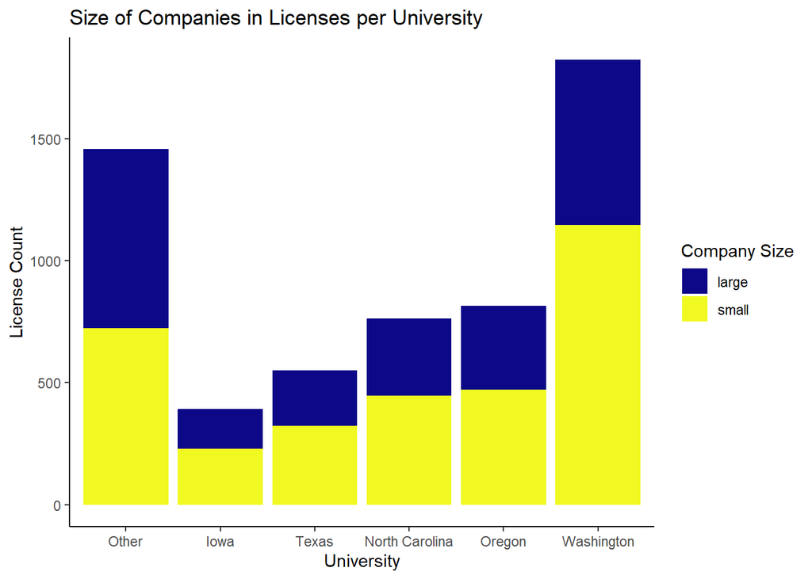

```r
licenses_joined_NA_sales <- licenses_joined %>%
  filter(!is.na(size_range_sales))

ggplot(licenses_joined_NA_sales, aes(x = top_uni, fill = size_range_sales)) +
  geom_bar() +
  theme(axis.text.x = element_text(angle=70, vjust=0.5)) +
  scale_fill_viridis_d(option = "C") +
  labs(title = "Size of Companies in Licenses per University",
       x = "University", y = "License Count", fill = "Company Size") +
  theme_classic()
```

## Company size per crop

The percentage of crops that are licensed to large companies by universities can be calculated by presenting FAO class per university with all licenses, then only those with large companies.

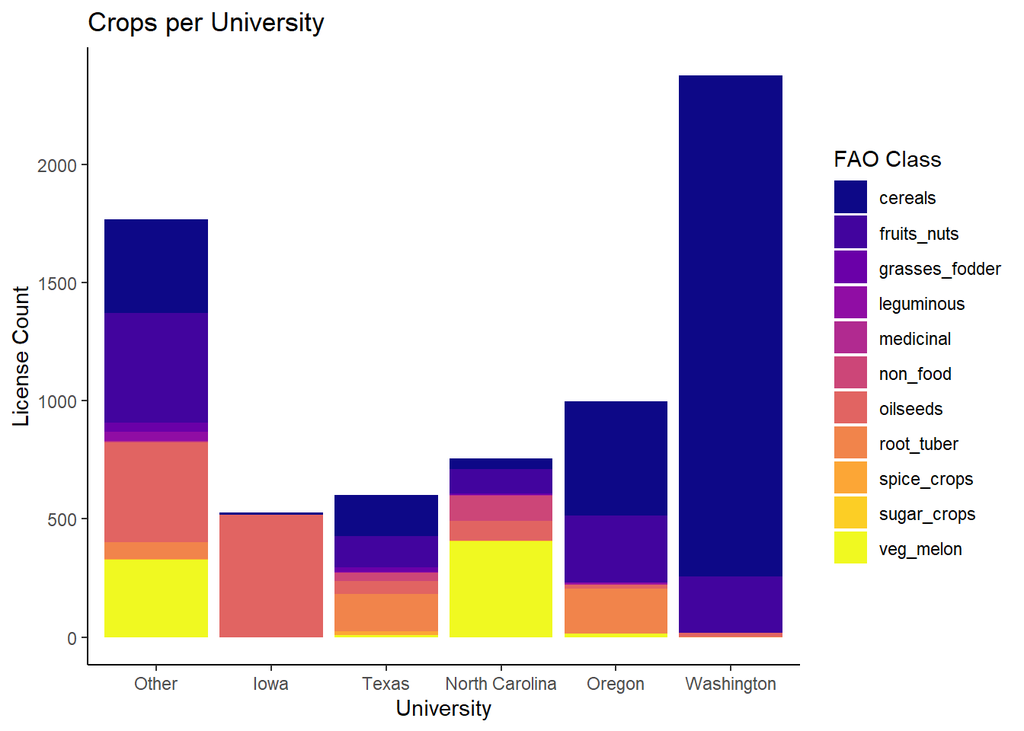

```r
licenses_joined_NA_fao_class1 <- licenses_joined %>%
  filter(!is.na(fao_class1))

ggplot(licenses_joined_NA_fao_class1, aes(x = top_uni, fill = fao_class1)) +
  geom_bar() +
  theme(axis.text.x = element_text(angle=70, vjust=0.5)) +
  scale_fill_viridis_d(option = "C") +
  labs(title = "Crops per University",
       x = "University", y = "License Count", fill = "FAO Class") +
  theme_classic()
```

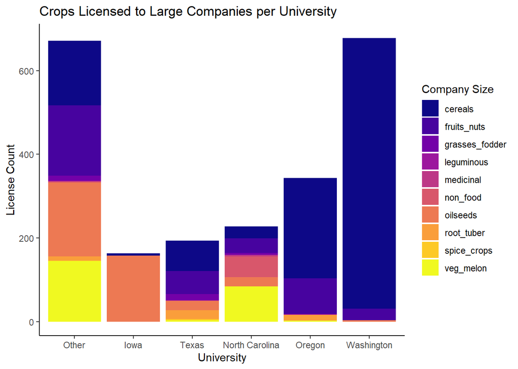

```r
licenses_joined_large <- licenses_joined %>%
  filter(size_range_sales == "large")

licenses_joined_large_NA_fao_class1 <- licenses_joined_large %>%
  filter(!is.na(fao_class1))

ggplot(licenses_joined_large_NA_fao_class1, aes(x = top_uni, fill = fao_class1)) +
  geom_bar() +
  theme(axis.text.x = element_text(angle=70, vjust=0.5)) +
  scale_fill_viridis_d(option = "C") +
  labs(title = "Crops Licensed to Large Companies per University",
       x = "University", y = "License Count", fill = "Company Size") +
  theme_classic()
```

In conclusion, this analysis report allows for specific university action to be investigated further. Large companies play a role in the movement of grant money at land grant universities.